# hw1_data_manipulation_and_visualization

## Kickstarter Dashboard

Kickstarter is a crowdfunding platform that aims to "help bring creative projects to life". The data was originally from https://www.kaggle.com/datasets/kemical/kickstarter-projects?resource=download.

```python
import pandas as pd
import matplotlib.pyplot as plt
import seaborn as sns
import holoviews as hv
import hvplot.pandas
import panel as pn
pn.extension()

import warnings
warnings.filterwarnings('ignore')
```

```python
data_df = pd.read_csv('kickstarter.csv')
```

```python
data_df.head()
```

|  | ID | name | category | main_category | country | currency | launched | deadline | goal | pledged | state | backers | usd_pledged_real | usd_goal_real |
| --- | --- | --- | --- | --- | --- | --- | --- | --- | --- | --- | --- | --- | --- | --- |
| 0 | 1000002330 | The Songs of Adelaide & Abullah | Poetry | Publishing | GB | GBP | 2015-08-11 12:12:28 | 2015-10-09 | 1000.0 | 0.0 | failed | 0 | 0.0 | 1533.95 |
| 1 | 1000003930 | Greeting From Earth: ZGAC Arts Capsule For ET | Narrative Film | Film & Video | US | USD | 2017-09-02 04:43:57 | 2017-11-01 | 30000.0 | 2421.0 | failed | 15 | 2421.0 | 30000.00 |
| 2 | 1000004038 | Where is Hank? | Narrative Film | Film & Video | US | USD | 2013-01-12 00:20:50 | 2013-02-26 | 45000.0 | 220.0 | failed | 3 | 220.0 | 45000.00 |
| 3 | 1000007540 | ToshiCapital Rekordz Needs Help to Complete Album | Music | Music | US | USD | 2012-03-17 03:24:11 | 2012-04-16 | 5000.0 | 1.0 | failed | 1 | 1.0 | 5000.00 |
| 4 | 1000011046 | Community Film Project: The Art of Neighborhoo... | Film & Video | Film & Video | US | USD | 2015-07-04 08:35:03 | 2015-08-29 | 19500.0 | 1283.0 | canceled | 14 | 1283.0 | 19500.00 |

```python
data_df.columns
```

```
Index(['ID', 'name', 'category', 'main_category', 'country', 'currency',
       'launched', 'deadline', 'goal', 'pledged', 'state', 'backers',
       'usd_pledged_real', 'usd_goal_real'],
      dtype='object')
```

### Turn Data into Specific Format

Change the format of columns, `launched` and `deadline`, to datetime and generate new columns to represent the `year` and `month` during which the project was `launched`

```python
# check the data type of each column
# data_df['launched'].dtype
data_df.dtypes
```

```
ID                    int64
name                 object
category             object
main_category        object
country              object
currency             object
launched             object
deadline             object
goal                float64
pledged             float64
state                object
backers               int64
usd_pledged_real    float64
usd_goal_real       float64
dtype: object
```

```python
# pd.to_datetime()
data_df['launched'] = pd.to_datetime(data_df['launched'])
data_df['deadline'] = pd.to_datetime(data_df['deadline'])
data_df.dtypes
```

```
ID                           int64
name                        object
category                    object
main_category               object
country                     object
currency                    object
launched            datetime64[ns]
deadline            datetime64[ns]
goal                       float64
pledged                    float64
state                       object
backers                      int64
usd_pledged_real           float64
usd_goal_real              float64
dtype: object
```

```python
# year, month, day, hour, minute, second
data_df['year_launched'] = data_df['launched'].dt.year
data_df['month_launched'] = data_df['launched'].dt.month
data_df.head()
```

|  | ID | name | category | main_category | country | currency | launched | deadline | goal | pledged | state | backers | usd_pledged_real | usd_goal_real | year_launched | month_launched |
| --- | --- | --- | --- | --- | --- | --- | --- | --- | --- | --- | --- | --- | --- | --- | --- | --- |
| 0 | 1000002330 | The Songs of Adelaide & Abullah | Poetry | Publishing | GB | GBP | 2015-08-11 12:12:28 | 2015-10-09 | 1000.0 | 0.0 | failed | 0 | 0.0 | 1533.95 | 2015 | 8 |
| 1 | 1000003930 | Greeting From Earth: ZGAC Arts Capsule For ET | Narrative Film | Film & Video | US | USD | 2017-09-02 04:43:57 | 2017-11-01 | 30000.0 | 2421.0 | failed | 15 | 2421.0 | 30000.00 | 2017 | 9 |
| 2 | 1000004038 | Where is Hank? | Narrative Film | Film & Video | US | USD | 2013-01-12 00:20:50 | 2013-02-26 | 45000.0 | 220.0 | failed | 3 | 220.0 | 45000.00 | 2013 | 1 |
| 3 | 1000007540 | ToshiCapital Rekordz Needs Help to Complete Album | Music | Music | US | USD | 2012-03-17 03:24:11 | 2012-04-16 | 5000.0 | 1.0 | failed | 1 | 1.0 | 5000.00 | 2012 | 3 |
| 4 | 1000011046 | Community Film Project: The Art of Neighborhoo... | Film & Video | Film & Video | US | USD | 2015-07-04 08:35:03 | 2015-08-29 | 19500.0 | 1283.0 | canceled | 14 | 1283.0 | 19500.00 | 2015 | 7 |

### Deal with Noisy data

Find out data with noisy launched time and decide whether to fix the noise or remove the noise

```python
data_df['year_launched'].value_counts()
```

```
2015    77300
2014    67745
2016    57184
2017    52200
2013    44851
2012    41165
2011    26237
2010    10519
2009     1329
2018      124
1970        7
Name: year_launched, dtype: int64
```

```python
data_df = data_df[data_df['year_launched'] != 1970]
```

```python
# check whether there is missing data in column 'year_launched'
data_df.isna().any()
```

```
ID                  False
name                 True
category            False
main_category       False
country             False
currency            False
launched            False
deadline            False
goal                False
pledged             False
state               False
backers             False
usd_pledged_real    False
usd_goal_real       False
year_launched       False
month_launched      False
dtype: bool
```

```python
data_df[data_df['name'].isna()]
```

|  | ID | name | category | main_category | country | currency | launched | deadline | goal | pledged | state | backers | usd_pledged_real | usd_goal_real | year_launched | month_launched |
| --- | --- | --- | --- | --- | --- | --- | --- | --- | --- | --- | --- | --- | --- | --- | --- | --- |
| 166851 | 1848699072 | NaN | Narrative Film | Film & Video | US | USD | 2012-01-01 12:35:31 | 2012-02-29 | 200000.0 | 100.0 | failed | 1 | 100.00 | 200000.00 | 2012 | 1 |
| 307234 | 634871725 | NaN | Video Games | Games | GB | GBP | 2012-12-19 23:57:48 | 2013-01-06 | 2000.0 | 196.0 | failed | 12 | 316.05 | 3224.97 | 2012 | 12 |
| 309991 | 648853978 | NaN | Product Design | Design | US | USD | 2016-06-18 05:01:47 | 2016-07-18 | 2500.0 | 0.0 | suspended | 0 | 0.00 | 2500.00 | 2016 | 6 |
| 338931 | 796533179 | NaN | Painting | Art | US | USD | 2011-11-06 23:55:55 | 2011-12-05 | 35000.0 | 220.0 | failed | 5 | 220.00 | 35000.00 | 2011 | 11 |

### Calculate Success rate

- Subplot 1: Use line chart to visualize the average success rate of projects (i.e., annual success rate) across years until 2017 (in other words, x-axis: year, y-axis: success rate)
- Subplot 2: Use a bar plot to display the number of projects per year (until 2017)

```python
# duration that is until 2017
data_df = data_df[data_df['year_launched'] < 2018]
```

```python
# success case
success = data_df[data_df['state'] == 'successful']
```

```python
# success case every year
all_data = data_df.groupby('year_launched')['ID'].count()
success_data = success.groupby('year_launched')['ID'].count()
```

```python
success_rate = success_data / all_data
success_data / all_data
```

```
year_launched
2009    0.435666
2010    0.436638
2011    0.463887
2012    0.434641
2013    0.432878
2014    0.311565
2015    0.271294
2016    0.328169
2017    0.353678
Name: ID, dtype: float64
```

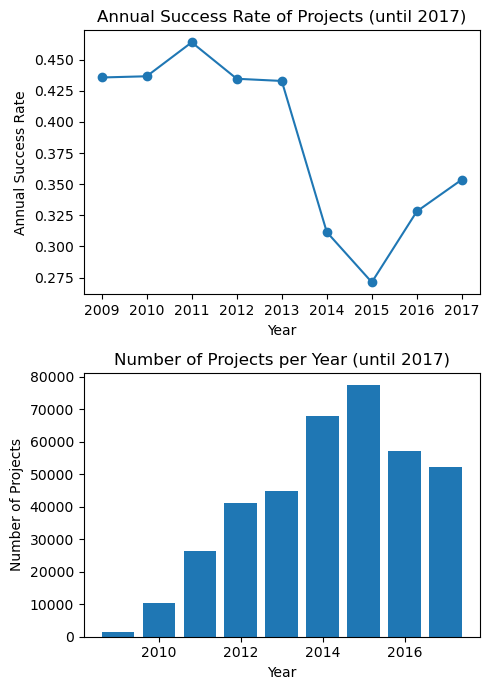

```python
# creates a figure (fig) and a set of subplots (axes)
fig, axes = plt.subplots(2, 1, figsize=(5, 7))

# Subplot 1: Line chart for annual success rate
axes[0].plot(success_rate.index, success_rate.values, marker='o', linestyle='-')
axes[0].set_xlabel('Year')
axes[0].set_ylabel('Annual Success Rate')
axes[0].set_title('Annual Success Rate of Projects (until 2017)')

# Subplot 2: the number of projects per year
axes[1].bar(all_data.index, all_data.values)
axes[1].set_xlabel('Year')
axes[1].set_ylabel('Number of Projects')
axes[1].set_title('Number of Projects per Year (until 2017)')

# Adjust layout for subplots
plt.tight_layout()
plt.show()
```

### Hypothesis and Exploration

Use a visualization to show preliminary results examining the hypothesis.

The success rate of different 'main_category' differs. From 2009 to 2017, year 2015 has the lowest annual success rate. I hypothsize that in the year 2015, the catefory with the lowest success rate takes a larger proportion of projects compared to other years.

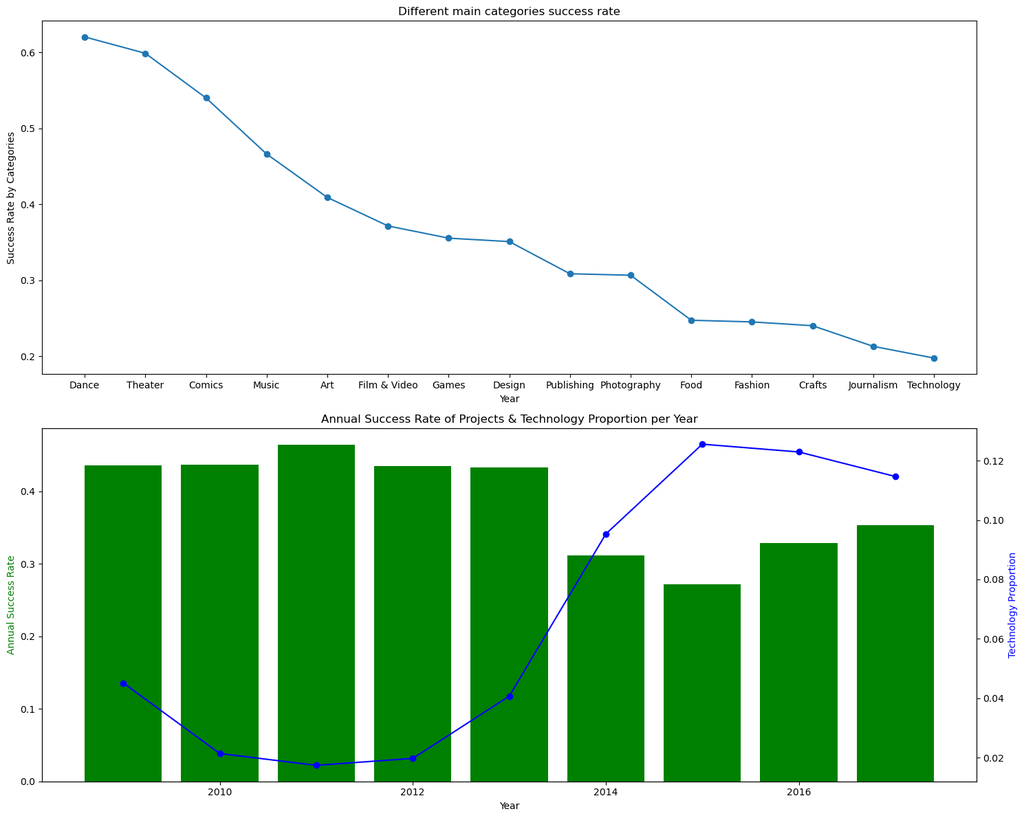

```python
# success rate of different categories
success_by_category = success.groupby('main_category')['ID'].count()
by_category = data_df.groupby('main_category')['ID'].count()
success_rate_by_category = (success_by_category / by_category).sort_values(ascending=False)

# Technology has the lowest success rate.
# Therefore, the next step is to check whether technology takes higher project proportion in 2015.
technology_df = data_df[data_df['main_category'] == 'Technology']
technology_rate = technology_df.groupby('year_launched')['ID'].count() / all_data

fig, axes = plt.subplots(2, 1, figsize=(15, 12))

# Subplot 1: Different main categories success rate
axes[0].plot(success_rate_by_category.index, success_rate_by_category.values, marker='o', linestyle='-')
axes[0].set_xlabel('Year')
axes[0].set_ylabel('Success Rate by Categories')
axes[0].set_title('Different main categories success rate')

# Subplot 2: the number of projects per year
axes[1].bar(success_rate.index, success_rate.values, color='g')
axes[1].set_xlabel('Year')
axes[1].set_ylabel('Annual Success Rate', color='g')
axes[1].set_title('Annual Success Rate of Projects & Technology Proportion per Year')

# Create a right axis that shares the same x-axis with the left axis
ax2 = axes[1].twinx()

ax2.plot(technology_rate.index, technology_rate.values, marker='o', linestyle='-', color='b', label='Technology')
ax2.set_ylabel('Technology Proportion', color='b')


plt.tight_layout()
plt.show()
```

The first graph shows that 'Technology' cateogry has the lowest success rate. The second graph shows that the year 2015 has the lowest annual success rate and highest proportion of 'Technology' category project.

### Implement Dashboard

Build an interactive dashboard following the requirements below:

1. Could choose from one of the three countries: US, France (FR), United Kingdom of Great Britain and Northern Ireland (GB)
2. Has a slider to choose the year of the visualization
3. Could choose to visualize either the number of projects or the number of success projects (as y-axis)
4. Has a line chart to visualize the y-axis across months of the year

```python
# filter and add the column we need in this exercise
columns_to_keep = ['ID', 'country', 'state', 'year_launched', 'month_launched']
idf = data_df[columns_to_keep]
idf = idf.groupby(['country', 'year_launched', 'month_launched', 'state']).count().reset_index()
idf['project_count'] = idf['ID']
```

```python
# Define a custom function to conditionally create the new column
def new_column(row):
    if row['state'] == 'successful':
        return row['project_count']
    else:
        return 0

# Apply the custom function to create the new column
idf['success_project_count'] = idf.apply(new_column, axis=1)
idf = idf.drop('ID', axis=1)
idf = idf.drop('state', axis=1)
idf
```

|  | country | year_launched | month_launched | project_count | success_project_count |
| --- | --- | --- | --- | --- | --- |
| 0 | AT | 2015 | 6 | 11 | 0 |
| 1 | AT | 2015 | 7 | 8 | 0 |
| 2 | AT | 2015 | 7 | 18 | 0 |
| 3 | AT | 2015 | 7 | 2 | 2 |
| 4 | AT | 2015 | 7 | 1 | 0 |
| ... | ... | ... | ... | ... | ... |
| 2837 | US | 2017 | 12 | 120 | 0 |
| 2838 | US | 2017 | 12 | 138 | 0 |
| 2839 | US | 2017 | 12 | 1322 | 0 |
| 2840 | US | 2017 | 12 | 106 | 106 |
| 2841 | US | 2017 | 12 | 4 | 0 |

2842 rows × 5 columns

```python
# Step 1: get interactive dataframe
idf = idf.interactive()
```

```python
# can choose one value
country = pn.widgets.RadioButtonGroup(
    name='Country',
    options=['US', 'FR', 'GB'],
    value=['US', 'FR', 'GB'],
    button_type='success',
    width_policy='max',
    sizing_mode='stretch_width' # same width
)
# country_list = ['US', 'FR', 'GB']
country
```

```python
# Step 2: choose the year of visualization
year = pn.widgets.IntSlider(name='Year', start= 2009, end=2017, step=1, sizing_mode='stretch_width')
year
```

[output not shown]

```python
# Step 3: can choose to visualize either the number of projects or the number of success projects
situation = pn.widgets.RadioButtonGroup(
        name = 'Status',
        options = ['project_count', 'success_project_count'],
        button_type='success',
        width_policy='max',
        sizing_mode='stretch_width'
        )

situation
```

```python
# combine
dashboard = (idf[(idf.year_launched == year) & (idf.country == country)
            ].groupby(['country', 'year_launched', 'month_launched'])[situation].sum()
            .to_frame()
            .reset_index()
            .reset_index(drop=True)
            )
dashboard
```

[output not shown]

```python
PALETTE = ["#ff6f69", "#ffcc5c", "#88d8b0"]
ihvplot = dashboard.hvplot(x='month_launched', y=situation, by='country', color=PALETTE, line_width=6, height=400)
ihvplot
```

```python
def environment():
    try:
        get_ipython()
        print('notebook')
        return str(get_ipython())
    except:
        print('server')
        return 'server'

env = environment()

if env=="server":
   theme="fast"
else:
   theme="simple"

pn.extension('tabulator', sizing_mode="stretch_width")
hv.extension('bokeh')
```

```
notebook
```

```python
# create table
itable = dashboard.pipe(pn.widgets.Tabulator, pagination='remote', page_size=10, theme=theme)
itable
```

```python
final_dashboard = pn.Column(pn.Row(year, country, situation), pn.Row(ihvplot.panel(),itable.panel()))
final_dashboard.servable()
```